# R Notebook

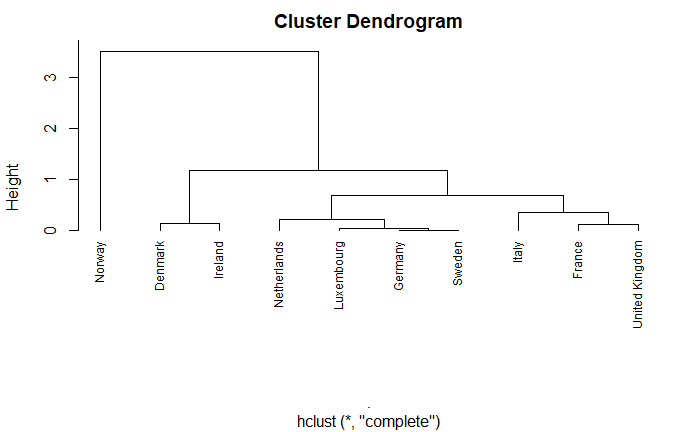

```r
clusters_b_e %>%
  plot(cex = 0.75, hang = -5)
```

Take productivity f

```r
diss_matrix_f <- prod_industry_data_scale %>%
              select(f) %>%
              dist(method = "euclidean")
```

Create a dissimilarity matrix showing distances

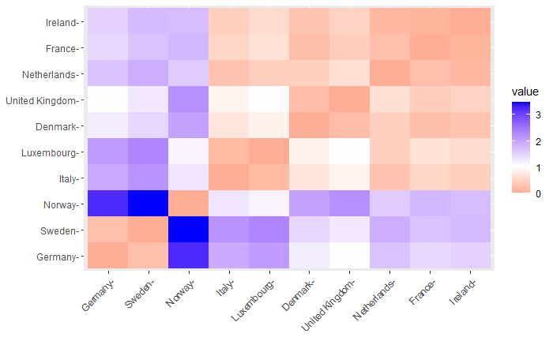

```r
fviz_dist(diss_matrix_f)
```

Build dendrogram

```r
clusters_f <- diss_matrix_f %>%
                 hclust(method = "complete")
```

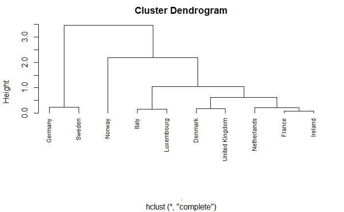

```r
clusters_f %>%
  plot(cex = 0.75, hang = -5)
```

Take productivity G-I

```r
diss_matrix_g_i <- prod_industry_data_scale %>%
              select(g_i) %>%
              dist(method = "euclidean")
```

Create a dissimilarity matrix showing distances

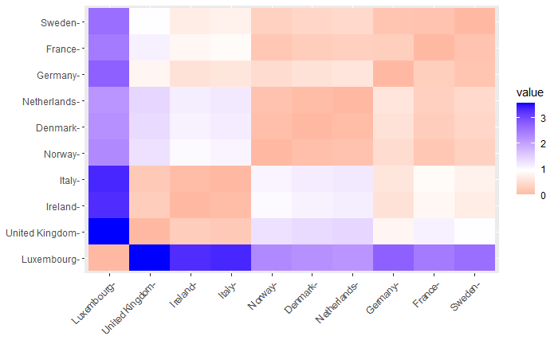

```r
fviz_dist(diss_matrix_g_i)
```

Build dendrogram

```r
clusters_g_i <- diss_matrix_g_i %>%
                 hclust(method = "complete")
```

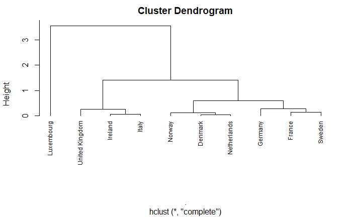

```r
clusters_g_i %>%
  plot(cex = 0.75, hang = -5)
```

Take productivity J

```r
diss_matrix_j <- prod_industry_data_scale %>%
              select(j) %>%
              dist(method = "euclidean")
```

Create a dissimilarity matrix showing distances

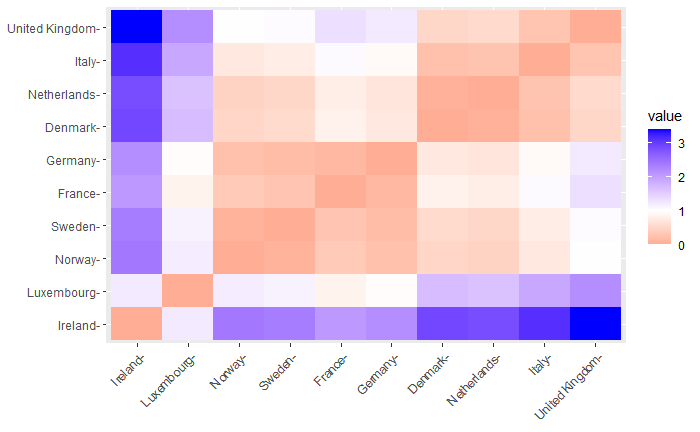

```r
fviz_dist(diss_matrix_j)
```

Build dendrogram

```r
clusters_j <- diss_matrix_j %>%
                 hclust(method = "complete")
```

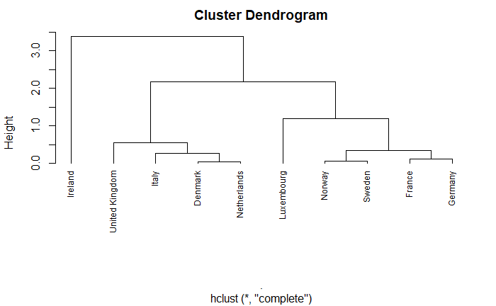

```r
clusters_j %>%
  plot(cex = 0.75, hang = -5)
```

Take productivity K

```r
diss_matrix_k <- prod_industry_data_scale %>%
              select(k) %>%
              dist(method = "euclidean")
```

Create a dissimilarity matrix showing distances

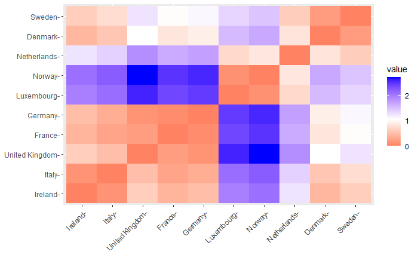

```r
fviz_dist(diss_matrix_k)
```

Build dendrogram

```r
clusters_k <- diss_matrix_k %>%
                 hclust(method = "complete")
```

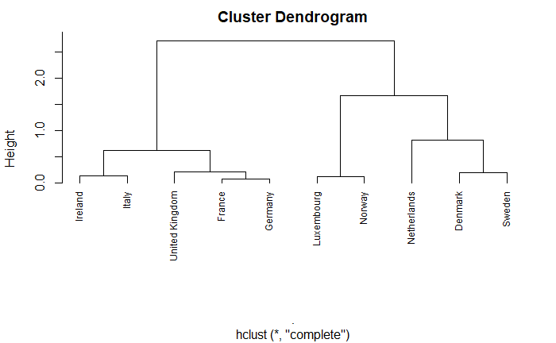

```r
clusters_k %>%
  plot(cex = 0.75, hang = -5)
```

Take productivity M-N

```r
diss_matrix_m_n <- prod_industry_data_scale %>%
              select(m_n) %>%
              dist(method = "euclidean")
```

Create a dissimilarity matrix showing distances

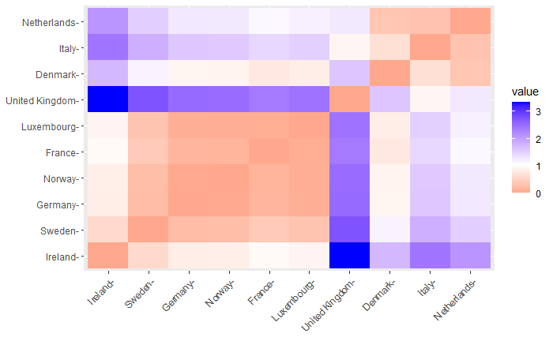

```r
fviz_dist(diss_matrix_m_n)
```

Build dendrogram

```r
clusters_m_n <- diss_matrix_m_n %>%
                 hclust(method = "complete")
```

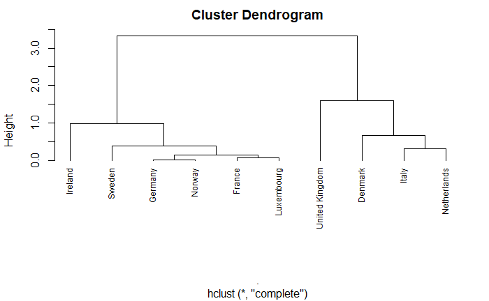

```r
clusters_m_n %>%
  plot(cex = 0.75, hang = -5)
```

Take productivity O-Q

```r
diss_matrix_o_q <- prod_industry_data_scale %>%
              select(o_q) %>%
              dist(method = "euclidean")
```

Create a dissimilarity matrix showing distances

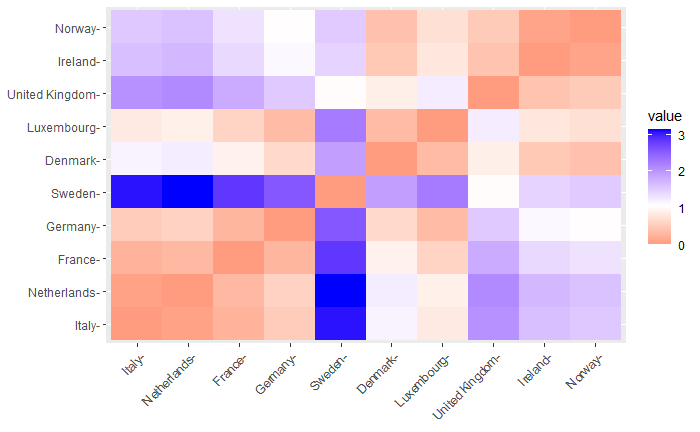

```r
fviz_dist(diss_matrix_o_q)
```

Build dendrogram

```r
clusters_o_q <- diss_matrix_o_q %>%
                 hclust(method = "complete")
```

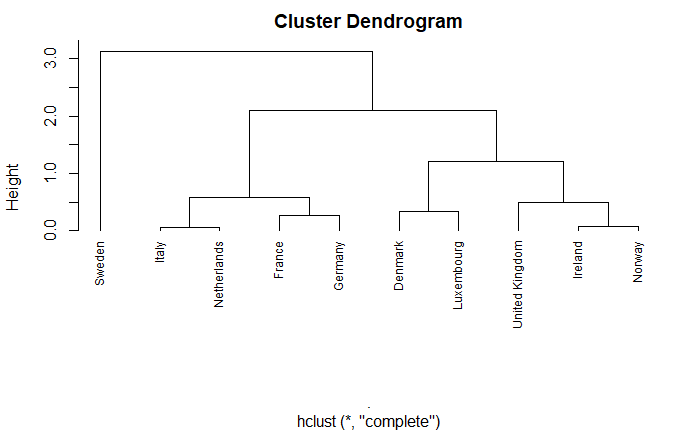

```r
clusters_o_q %>%
  plot(cex = 0.75, hang = -5)
```

Take productivity R-U

```r
diss_matrix_r_u <- prod_industry_data_scale %>%
              select(r_u) %>%
              dist(method = "euclidean")
```

Create a dissimilarity matrix showing distances

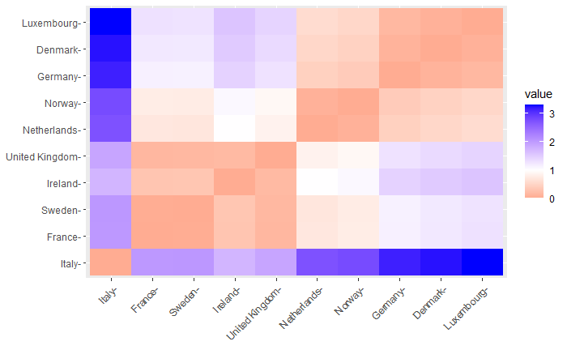

```r
fviz_dist(diss_matrix_r_u)
```

Build dendrogram

```r
clusters_r_u <- diss_matrix_r_u %>%
                 hclust(method = "complete")
```

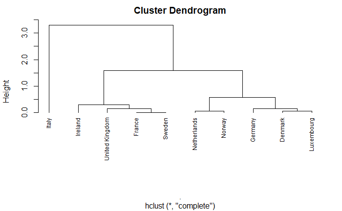

```r
clusters_r_u %>%
  plot(cex = 0.75, hang = -5)
```

```r
prod_industry_phw %>%
  select(`A*10 (excl L)`, `NACE Industry`)
```

| A*10 (excl L) | NACE Industry |
| --- | --- |
| A | Agriculture, forestry and fishing |
| B-E | Industry (except construction) |
| F | Construction |
| G-I | Wholesale and retail trade, transport, accommodation and food service activities |
| J | Information and communication |
| K | Financial and insurance activities |
| M-N | Professional, scientific and technical activities; administrative and support service activities |
| O-Q | Public administration, defence, education, human health and social work activities |
| R-U | Arts, entertainment and recreation; other service activities |